# EDA on The Red Wine Dataset

Ahmed Almohammed

June 16, 2022

> This is a short EDA on the assigned Red Wine Dataset for individual assignment 2.

# Data

> Initialize the dataset

```r
# load the dataset
red_wine_tibble  <- as_tibble(read.csv(here("data/winequality-red.csv")))

# store the variable names to ease the process of making the static table
tibble_names  <- names(red_wine_tibble)
```

## Static

| Variables | Description |
| --- | --- |
| fixed.acidity | most acids involved with wine |
| volatile.acidity | the amount of acetic acid in wine |
| citric.acid | adds freshness and flavor to wine |
| residual.sugar | amount of sugar remaining after fermentation |
| chlorides | amount of salt in wine |
| free.sulfur.dioxide | prevents microbial growth and oxidation |
| total.sulfur.dioxide | the amount of free and bound SO2 |
| density | density depending on alcohol and sugar levels in wine |
| pH | describes the acidity of wine |
| sulphates | acts as antimicrobial and antioxidant |
| alcohol | percent of alcohol content in wine |
| quality | the output value based on the above variables |

## Interactive

```r
# First 10 observations
kbl(red_wine_tibble[1:10,])  %>%
      kable_styling(bootstrap_options = c("striped", "hover", "condensed", "responsive"))
```

| fixed.acidity | volatile.acidity | citric.acid | residual.sugar | chlorides | free.sulfur.dioxide | total.sulfur.dioxide | density | pH | sulphates | alcohol | quality |
| --- | --- | --- | --- | --- | --- | --- | --- | --- | --- | --- | --- |
| 7.4 | 0.70 | 0.00 | 1.9 | 0.076 | 11 | 34 | 0.9978 | 3.51 | 0.56 | 9.4 | 5 |
| 7.8 | 0.88 | 0.00 | 2.6 | 0.098 | 25 | 67 | 0.9968 | 3.20 | 0.68 | 9.8 | 5 |
| 7.8 | 0.76 | 0.04 | 2.3 | 0.092 | 15 | 54 | 0.9970 | 3.26 | 0.65 | 9.8 | 5 |
| 11.2 | 0.28 | 0.56 | 1.9 | 0.075 | 17 | 60 | 0.9980 | 3.16 | 0.58 | 9.8 | 6 |
| 7.4 | 0.70 | 0.00 | 1.9 | 0.076 | 11 | 34 | 0.9978 | 3.51 | 0.56 | 9.4 | 5 |
| 7.4 | 0.66 | 0.00 | 1.8 | 0.075 | 13 | 40 | 0.9978 | 3.51 | 0.56 | 9.4 | 5 |
| 7.9 | 0.60 | 0.06 | 1.6 | 0.069 | 15 | 59 | 0.9964 | 3.30 | 0.46 | 9.4 | 5 |
| 7.3 | 0.65 | 0.00 | 1.2 | 0.065 | 15 | 21 | 0.9946 | 3.39 | 0.47 | 10.0 | 7 |
| 7.8 | 0.58 | 0.02 | 2.0 | 0.073 | 9 | 18 | 0.9968 | 3.36 | 0.57 | 9.5 | 7 |
| 7.5 | 0.50 | 0.36 | 6.1 | 0.071 | 17 | 102 | 0.9978 | 3.35 | 0.80 | 10.5 | 5 |

# EDA

## General Overview of the Dataset

```r
# check the first and last 6 observations of the dataset
head(red_wine_tibble)
## # A tibble: 6 × 12
##   fixed.acidity volatile.acidity citric.acid residual.sugar chlorides
##           <dbl>            <dbl>       <dbl>          <dbl>     <dbl>
## 1           7.4             0.7         0               1.9     0.076
## 2           7.8             0.88        0               2.6     0.098
## 3           7.8             0.76        0.04            2.3     0.092
## 4          11.2             0.28        0.56            1.9     0.075
## 5           7.4             0.7         0               1.9     0.076
## 6           7.4             0.66        0               1.8     0.075
## # … with 7 more variables: free.sulfur.dioxide <dbl>,
## #   total.sulfur.dioxide <dbl>, density <dbl>, pH <dbl>, sulphates <dbl>,
## #   alcohol <dbl>, quality <int>
tail(red_wine_tibble)
## # A tibble: 6 × 12
##   fixed.acidity volatile.acidity citric.acid residual.sugar chlorides
##           <dbl>            <dbl>       <dbl>          <dbl>     <dbl>
## 1           6.8            0.62         0.08            1.9     0.068
## 2           6.2            0.6          0.08            2       0.09
## 3           5.9            0.55         0.1             2.2     0.062
## 4           6.3            0.51         0.13            2.3     0.076
## 5           5.9            0.645        0.12            2       0.075
## 6           6              0.31         0.47            3.6     0.067
## # … with 7 more variables: free.sulfur.dioxide <dbl>,
## #   total.sulfur.dioxide <dbl>, density <dbl>, pH <dbl>, sulphates <dbl>,
## #   alcohol <dbl>, quality <int>
```

```r
# get a summary on the whole dataset
summary(red_wine_tibble)
```

```
##  fixed.acidity   volatile.acidity  citric.acid    residual.sugar
##  Min.   : 4.60   Min.   :0.1200   Min.   :0.000   Min.   : 0.900
##  1st Qu.: 7.10   1st Qu.:0.3900   1st Qu.:0.090   1st Qu.: 1.900
##  Median : 7.90   Median :0.5200   Median :0.260   Median : 2.200
##  Mean   : 8.32   Mean   :0.5278   Mean   :0.271   Mean   : 2.539
##  3rd Qu.: 9.20   3rd Qu.:0.6400   3rd Qu.:0.420   3rd Qu.: 2.600
##  Max.   :15.90   Max.   :1.5800   Max.   :1.000   Max.   :15.500
##    chlorides       free.sulfur.dioxide total.sulfur.dioxide    density
##  Min.   :0.01200   Min.   : 1.00       Min.   :  6.00       Min.   :0.9901
##  1st Qu.:0.07000   1st Qu.: 7.00       1st Qu.: 22.00       1st Qu.:0.9956
##  Median :0.07900   Median :14.00       Median : 38.00       Median :0.9968
##  Mean   :0.08747   Mean   :15.87       Mean   : 46.47       Mean   :0.9967
##  3rd Qu.:0.09000   3rd Qu.:21.00       3rd Qu.: 62.00       3rd Qu.:0.9978
##  Max.   :0.61100   Max.   :72.00       Max.   :289.00       Max.   :1.0037
##        pH          sulphates         alcohol         quality
##  Min.   :2.740   Min.   :0.3300   Min.   : 8.40   Min.   :3.000
##  1st Qu.:3.210   1st Qu.:0.5500   1st Qu.: 9.50   1st Qu.:5.000
##  Median :3.310   Median :0.6200   Median :10.20   Median :6.000
##  Mean   :3.311   Mean   :0.6581   Mean   :10.42   Mean   :5.636
##  3rd Qu.:3.400   3rd Qu.:0.7300   3rd Qu.:11.10   3rd Qu.:6.000
##  Max.   :4.010   Max.   :2.0000   Max.   :14.90   Max.   :8.000
```

```r
# get a glimpse on the dataset
glimpse(red_wine_tibble)
```

```
## Rows: 1,599
## Columns: 12
## $ fixed.acidity        <dbl> 7.4, 7.8, 7.8, 11.2, 7.4, 7.4, 7.9, 7.3, 7.8, 7.5…
## $ volatile.acidity     <dbl> 0.700, 0.880, 0.760, 0.280, 0.700, 0.660, 0.600, …
## $ citric.acid          <dbl> 0.00, 0.00, 0.04, 0.56, 0.00, 0.00, 0.06, 0.00, 0…
## $ residual.sugar       <dbl> 1.9, 2.6, 2.3, 1.9, 1.9, 1.8, 1.6, 1.2, 2.0, 6.1,…
## $ chlorides            <dbl> 0.076, 0.098, 0.092, 0.075, 0.076, 0.075, 0.069, …
## $ free.sulfur.dioxide  <dbl> 11, 25, 15, 17, 11, 13, 15, 15, 9, 17, 15, 17, 16…
## $ total.sulfur.dioxide <dbl> 34, 67, 54, 60, 34, 40, 59, 21, 18, 102, 65, 102,…
## $ density              <dbl> 0.9978, 0.9968, 0.9970, 0.9980, 0.9978, 0.9978, 0…
## $ pH                   <dbl> 3.51, 3.20, 3.26, 3.16, 3.51, 3.51, 3.30, 3.39, 3…
## $ sulphates            <dbl> 0.56, 0.68, 0.65, 0.58, 0.56, 0.56, 0.46, 0.47, 0…
## $ alcohol              <dbl> 9.4, 9.8, 9.8, 9.8, 9.4, 9.4, 9.4, 10.0, 9.5, 10.…
## $ quality              <int> 5, 5, 5, 6, 5, 5, 5, 7, 7, 5, 5, 5, 5, 5, 5, 5, 7…
```

```r
# get the status of the dataset
status(red_wine_tibble)
```

```
##                                  variable q_zeros    p_zeros q_na p_na q_inf
## fixed.acidity               fixed.acidity       0 0.00000000    0    0     0
## volatile.acidity         volatile.acidity       0 0.00000000    0    0     0
## citric.acid                   citric.acid     132 0.08255159    0    0     0
## residual.sugar             residual.sugar       0 0.00000000    0    0     0
## chlorides                       chlorides       0 0.00000000    0    0     0
## free.sulfur.dioxide   free.sulfur.dioxide       0 0.00000000    0    0     0
## total.sulfur.dioxide total.sulfur.dioxide       0 0.00000000    0    0     0
## density                           density       0 0.00000000    0    0     0
## pH                                     pH       0 0.00000000    0    0     0
## sulphates                       sulphates       0 0.00000000    0    0     0
## alcohol                           alcohol       0 0.00000000    0    0     0
## quality                           quality       0 0.00000000    0    0     0
##                      p_inf    type unique
## fixed.acidity            0 numeric     96
## volatile.acidity         0 numeric    143
## citric.acid              0 numeric     80
## residual.sugar           0 numeric     91
## chlorides                0 numeric    153
## free.sulfur.dioxide      0 numeric     60
## total.sulfur.dioxide     0 numeric    144
## density                  0 numeric    436
## pH                       0 numeric     89
## sulphates                0 numeric     96
## alcohol                  0 numeric     65
## quality                  0 integer      6
```

```r
# get a stat description on the variables in the dataset
describe(red_wine_tibble)
```

```
## red_wine_tibble
##
##  12  Variables      1599  Observations
## --------------------------------------------------------------------------------
## fixed.acidity
##        n  missing distinct     Info     Mean      Gmd      .05      .10
##     1599        0       96    0.999     8.32    1.893      6.1      6.5
##      .25      .50      .75      .90      .95
##      7.1      7.9      9.2     10.7     11.8
##
## lowest :  4.6  4.7  4.9  5.0  5.1, highest: 14.3 15.0 15.5 15.6 15.9
## --------------------------------------------------------------------------------
## volatile.acidity
##        n  missing distinct     Info     Mean      Gmd      .05      .10
##     1599        0      143        1   0.5278    0.199    0.270    0.310
##      .25      .50      .75      .90      .95
##    0.390    0.520    0.640    0.745    0.840
##
## lowest : 0.120 0.160 0.180 0.190 0.200, highest: 1.180 1.185 1.240 1.330 1.580
## --------------------------------------------------------------------------------
## citric.acid
##        n  missing distinct     Info     Mean      Gmd      .05      .10
##     1599        0       80    0.999    0.271   0.2227    0.000    0.010
##      .25      .50      .75      .90      .95
##    0.090    0.260    0.420    0.522    0.600
##
## lowest : 0.00 0.01 0.02 0.03 0.04, highest: 0.75 0.76 0.78 0.79 1.00
## --------------------------------------------------------------------------------
## residual.sugar
##        n  missing distinct     Info     Mean      Gmd      .05      .10
##     1599        0       91    0.996    2.539    1.078     1.59     1.70
##      .25      .50      .75      .90      .95
##     1.90     2.20     2.60     3.60     5.10
##
## lowest :  0.9  1.2  1.3  1.4  1.5, highest: 13.4 13.8 13.9 15.4 15.5
## --------------------------------------------------------------------------------
## chlorides
##        n  missing distinct     Info     Mean      Gmd      .05      .10
##     1599        0      153        1  0.08747  0.03217   0.0540   0.0600
##      .25      .50      .75      .90      .95
```

[output cut: 49 more lines]

```
##      9.5     10.2     11.1     12.0     12.5
##
## lowest :  8.40000  8.50000  8.70000  8.80000  9.00000
## highest: 13.50000 13.56667 13.60000 14.00000 14.90000
## --------------------------------------------------------------------------------
## quality
##        n  missing distinct     Info     Mean      Gmd
##     1599        0        6    0.857    5.636   0.8431
##
## lowest : 3 4 5 6 7, highest: 4 5 6 7 8
##
## Value          3     4     5     6     7     8
## Frequency     10    53   681   638   199    18
## Proportion 0.006 0.033 0.426 0.399 0.124 0.011
## --------------------------------------------------------------------------------
```

> **Based on the above overview, we observe the following:**
- There are 12 variables, 11 of whom contribute to the last variable, which is `quality`
- There are 1599 rows and 12 columns that make up this dataset
- `citric.acid` variable contains 132 `0` values, which might need to be accounted for during analysis
- All the variables are of type of numeric, except the `quality`, which comes as an integer.
- `quality` variable is a scale form 1 to 10, however, in this dataset the minimum is `3` and the maximum is `8`.

Before we proceed to the next section, we notice that our variables are not formatted properly, thus we will tidy them up using the `clean_names()` function.

```r
# clean the data for any undesired forms
red_wine_cleaned <- clean_names(dat = red_wine_tibble)
```

## Plotting the Variables

We will conduct a series of plotting to better understand the dataset.

### Univariate Plot

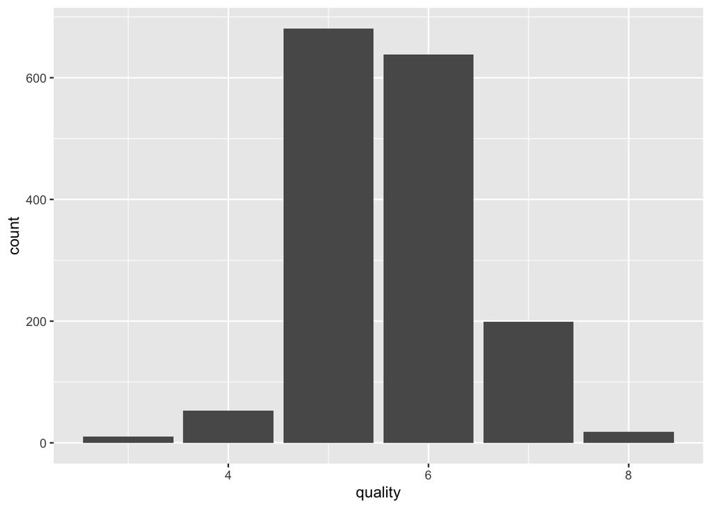

```r
# plot the quality variable
ggplot(red_wine_cleaned) +
    geom_bar(aes(quality))
```

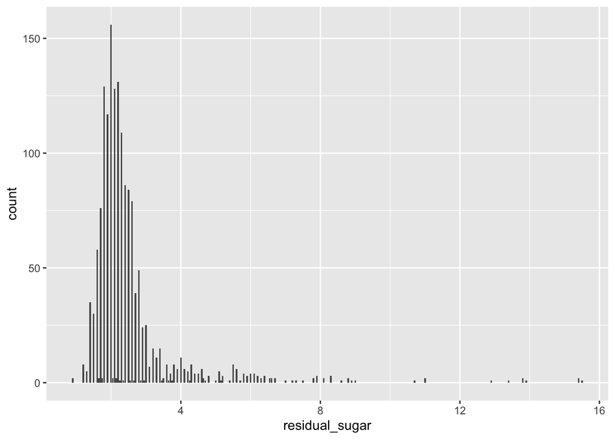

```r
# plot the residual_sugar variable
ggplot(red_wine_cleaned) +
    geom_bar(aes(residual_sugar))
```

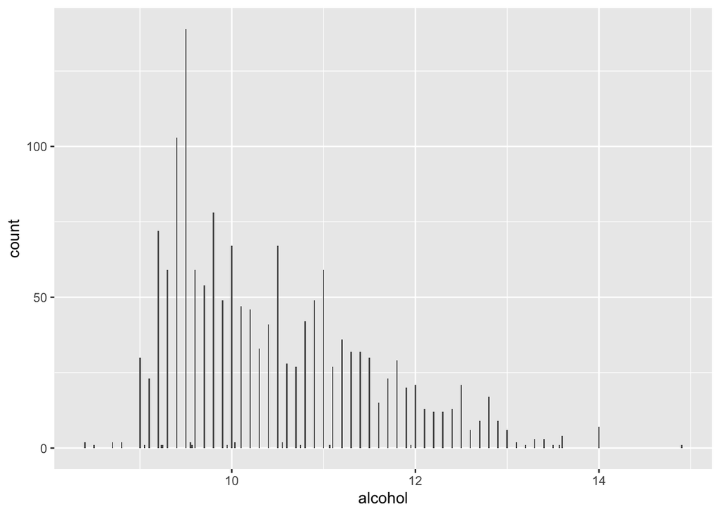

```r
# plot the alcohol variable
ggplot(red_wine_cleaned) +
    geom_bar(aes(alcohol))
```

> **We can notice the following:**
- Most of the wines are of `quality` 5 & 6
- In plotting the `residual_sugar` variable, the graph is skewed to the right
- In plotting the `alcohol` variable, the graph is skewed to the right

### Multivariate Plot

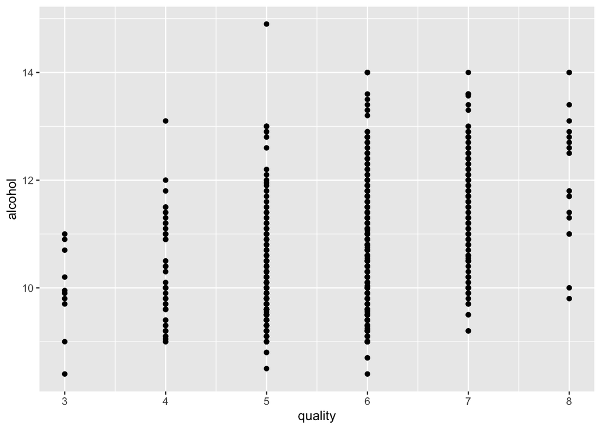

```r
# plot both the quality and alcohol variables
ggplot(red_wine_cleaned) +
    geom_point(aes(quality, alcohol))
```

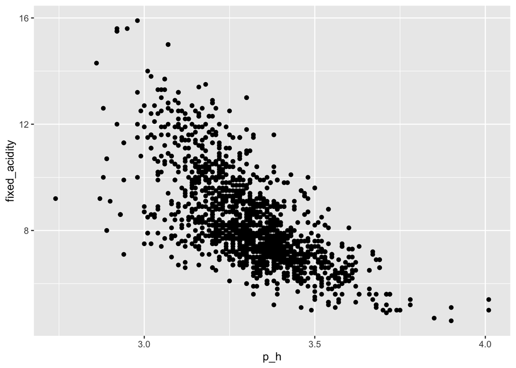

```r
# plot both the ph and fixed_acidity variables
ggplot(red_wine_cleaned) +
    geom_point(aes(p_h, fixed_acidity))
```

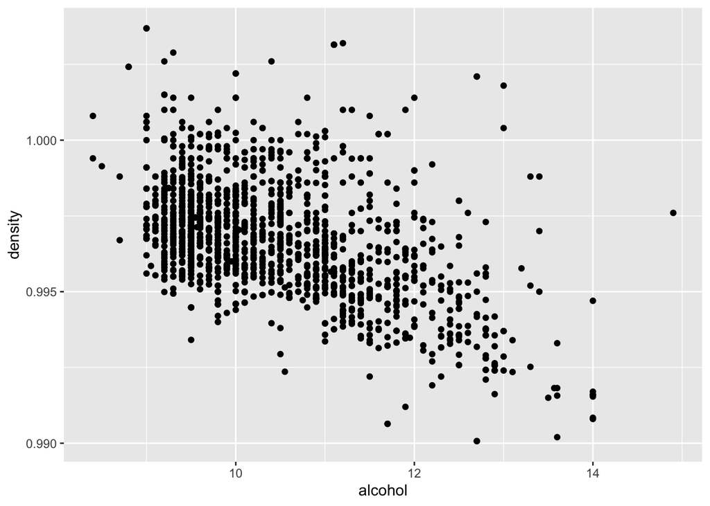

```r
# plot both the alcohol and density variables
ggplot(red_wine_cleaned) +
    geom_point(aes(alcohol, density))
```

> **We can notice the following:**
- High `alcohol` levels tend to be present in higher `quality` wine
- As the `ph` level increases, the `fixed acidity` decreases
- `Density` of the wine decreases as alcohol levels increase

### Plot the correlation matrix to verify our findings

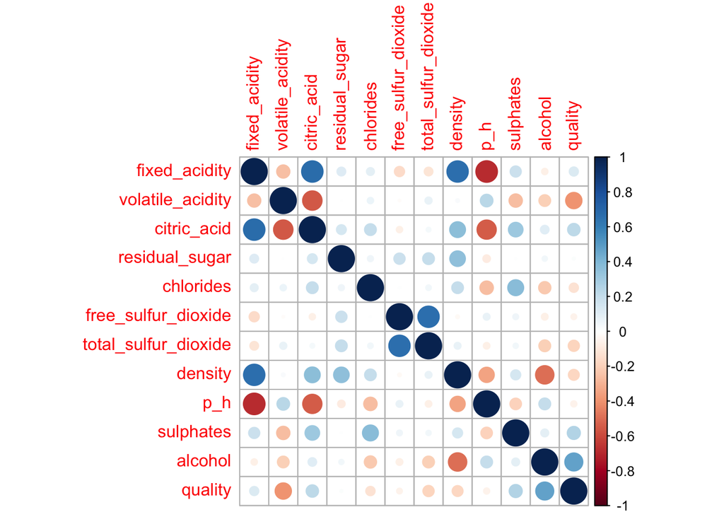

```r
corrplot(cor(red_wine_cleaned))
```

# Conclusion

> In conclusion, we saw how different variables correlated to each other through the various graphs plotted, alongside the correlation matrix that confirmed this study. We also noticed how most of the wine in this dataset is mostly labeled as either of quality 5 or 6, few of which are outliers. This is just a basic EDA, as there is more to uncover from this rich dataset.